# Telecom Customer Churn

```python
import numpy as np
import pandas as pd
import matplotlib.pyplot as plt
import seaborn as sns
from sklearn.linear_model import LogisticRegression
```

```python
df = pd.read_csv('Path/Telecom Data.csv')
df.head()
```

|  | customerID | gender | SeniorCitizen | Partner | Dependents | tenure | PhoneService | MultipleLines | InternetService | OnlineSecurity | ... | DeviceProtection | TechSupport | StreamingTV | StreamingMovies | Contract | PaperlessBilling | PaymentMethod | MonthlyCharges | TotalCharges | Churn |
| --- | --- | --- | --- | --- | --- | --- | --- | --- | --- | --- | --- | --- | --- | --- | --- | --- | --- | --- | --- | --- | --- |
| 0 | 7590-VHVEG | Female | No | Yes | No | 1 | No | No phone service | DSL | No | ... | No | No | No | No | Month-to-month | Yes | Electronic check | 29.85 | 29.85 | No |
| 1 | 5575-GNVDE | Male | No | No | No | 34 | Yes | No | DSL | Yes | ... | Yes | No | No | No | One year | No | Mailed check | 56.95 | 1889.50 | No |
| 2 | 3668-QPYBK | Male | No | No | No | 2 | Yes | No | DSL | Yes | ... | No | No | No | No | Month-to-month | Yes | Mailed check | 53.85 | 108.15 | Yes |
| 3 | 7795-CFOCW | Male | No | No | No | 45 | No | No phone service | DSL | Yes | ... | Yes | Yes | No | No | One year | No | Bank transfer (automatic) | 42.30 | 1840.75 | No |
| 4 | 9237-HQITU | Female | No | No | No | 2 | Yes | No | Fiber optic | No | ... | No | No | No | No | Month-to-month | Yes | Electronic check | 70.70 | 151.65 | Yes |

5 rows × 21 columns

```python
df.info()
```

```
<class 'pandas.core.frame.DataFrame'>
RangeIndex: 7032 entries, 0 to 7031
Data columns (total 21 columns):
 #   Column            Non-Null Count  Dtype
---  ------            --------------  -----
 0   customerID        7032 non-null   object
 1   gender            7032 non-null   object
 2   SeniorCitizen     7032 non-null   object
 3   Partner           7032 non-null   object
 4   Dependents        7032 non-null   object
 5   tenure            7032 non-null   int64
 6   PhoneService      7032 non-null   object
 7   MultipleLines     7032 non-null   object
 8   InternetService   7032 non-null   object
 9   OnlineSecurity    7032 non-null   object
 10  OnlineBackup      7032 non-null   object
 11  DeviceProtection  7032 non-null   object
 12  TechSupport       7032 non-null   object
 13  StreamingTV       7032 non-null   object
 14  StreamingMovies   7032 non-null   object
 15  Contract          7032 non-null   object
 16  PaperlessBilling  7032 non-null   object
 17  PaymentMethod     7032 non-null   object
 18  MonthlyCharges    7032 non-null   float64
 19  TotalCharges      7032 non-null   float64
 20  Churn             7032 non-null   object
dtypes: float64(2), int64(1), object(18)
memory usage: 1.1+ MB
```

# This dataset has 7,032 samples, and 21 attributes (1 integer, 2 float, and 18 objects)

# No variable column has null/missing values

# Each user is identified through a unique customer ID. There are 19 independent variables used to predict the target variable – customer churn. In this dataset, customer churn is defined as users who have left within the last month

```python
churn = df.groupby('Churn')
churn.mean()
#churn.mean('tenure', 'MonthlyCharges', 'TotalCharges')
```

| Churn | tenure | MonthlyCharges | TotalCharges |
| --- | --- | --- | --- |
| No | 37.650010 | 61.307408 | 2555.344141 |
| Yes | 17.979133 | 74.441332 | 1531.796094 |

# Customers who have been with the company for shorter tenure and are generating higher monthly charges prefer to unsubscribe the services

```python
#Let’s count the number of customers in the dataset who have churned

df['Churn'].value_counts()
```

```
No     5163
Yes    1869
Name: Churn, dtype: int64
```

```python
df.Churn.value_counts(normalize=True)
```

```
No     0.734215
Yes    0.265785
Name: Churn, dtype: float64
```

```python
# Convert the object to int
df.Churn = (df.Churn == 'Yes').astype(int)
df.Churn
```

```
0       0
1       0
2       1
3       0
4       1
       ..
7027    0
7028    0
7029    0
7030    1
7031    0
Name: Churn, Length: 7032, dtype: int32
```

# Out of 7,032 customers, 1869 left, and 5163 stayed. The no. of coustmers left is approx 27% of the total employment

```python
churn_female = df[df.gender == 'Female'].Churn.mean()
churn_female
```

```
0.2695951765719208
```

```python
churn_male = df[df.gender == 'Male'].Churn.mean()
churn_male
```

```
0.26204564666103125
```

```python
churn_senior = df[df.SeniorCitizen == 'Yes'].Churn.mean()
churn_senior
```

```
0.4168126094570928
```

```python
churn_nosenior = df[df.SeniorCitizen == 'No'].Churn.mean()
churn_nosenior
```

```
0.2365025466893039
```

```python
churn_partner = df[df.Partner == 'Yes'].Churn.mean()
churn_partner
```

```
0.1971706454465075
```

```python
churn_no_partner = df[df.Partner == 'No'].Churn.mean()
churn_no_partner
```

```
0.3297609233305853
```

# Exploratory Data Analysis (EDA)

Now, let’s perform some exploratory data analysis to gain a better understanding of the independent variables in the dataset and their relationship with customer churn

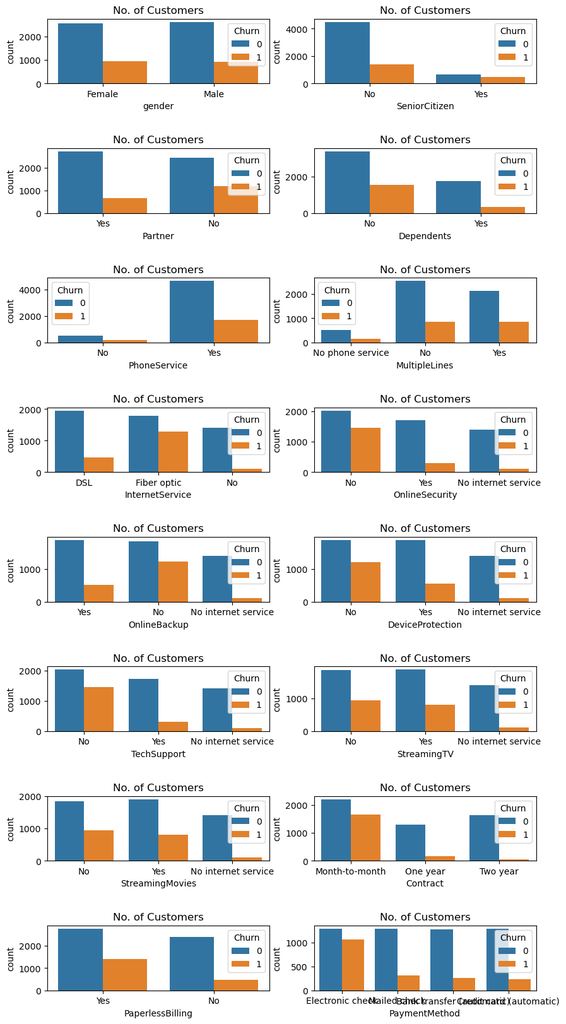

```python
features=['gender','SeniorCitizen','Partner','Dependents','PhoneService','MultipleLines', 'InternetService',
          'OnlineSecurity', 'OnlineBackup','DeviceProtection','TechSupport','StreamingTV','StreamingMovies','Contract',
          'PaperlessBilling','PaymentMethod']
plt.subplots(figsize=(10,20))
for i, j in enumerate(features):       #The enumerate function is used to iterate over the list (i)
    plt.subplot(8, 2, i+1)             #Inside the loop, plt.subplot(4, 2, i+1) is used to create a subplot with 4 rows and 2 columns, and the index of the current feature is used to determine the position of the subplot
    plt.subplots_adjust(hspace = 1.0)  #The subplots_adjust() function is used to adjust the spacing between the subplots
    sns.countplot(x=j, data = df, hue='Churn')      #seaborn.countplot() function is used to show the counts of observations in each categorical variable
    plt.xticks(rotation=0)
    plt.title('No. of Customers')

    #The hue parameter is set to 'Churn', which will create a countplot for customers who left and those who didn't
```

```python
numeric=['MonthlyCharges', 'tenure', 'TotalCharges']
```

```
MonthlyCharges
```

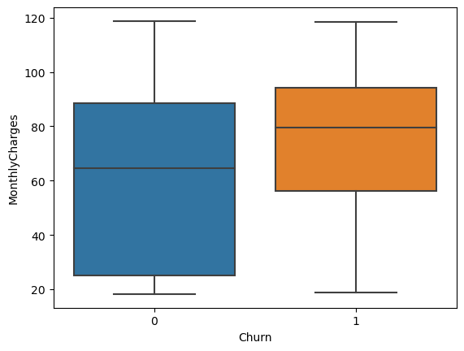

```
tenure
```

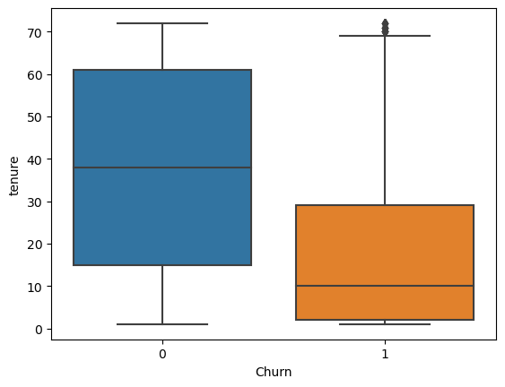

```
TotalCharges
```

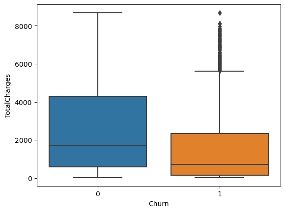

```python
i = 0

while i<len(numeric):
    print (numeric[i])
    sns.boxplot(x='Churn', y=numeric[i], data=df)
    plt.show()
    i+=1
```

# Building a Prediction Model

# Pre-Processing Data

```python
df.info()
```

```
<class 'pandas.core.frame.DataFrame'>
RangeIndex: 7032 entries, 0 to 7031
Data columns (total 21 columns):
 #   Column            Non-Null Count  Dtype
---  ------            --------------  -----
 0   customerID        7032 non-null   object
 1   gender            7032 non-null   object
 2   SeniorCitizen     7032 non-null   object
 3   Partner           7032 non-null   object
 4   Dependents        7032 non-null   object
 5   tenure            7032 non-null   int64
 6   PhoneService      7032 non-null   object
 7   MultipleLines     7032 non-null   object
 8   InternetService   7032 non-null   object
 9   OnlineSecurity    7032 non-null   object
 10  OnlineBackup      7032 non-null   object
 11  DeviceProtection  7032 non-null   object
 12  TechSupport       7032 non-null   object
 13  StreamingTV       7032 non-null   object
 14  StreamingMovies   7032 non-null   object
 15  Contract          7032 non-null   object
 16  PaperlessBilling  7032 non-null   object
 17  PaymentMethod     7032 non-null   object
 18  MonthlyCharges    7032 non-null   float64
 19  TotalCharges      7032 non-null   float64
 20  Churn             7032 non-null   int32
dtypes: float64(2), int32(1), int64(1), object(17)
memory usage: 1.1+ MB
```

```python
numerical = ['tenure', 'MonthlyCharges', 'TotalCharges']
```

```python
categorical = [
    'SeniorCitizen',
    'Partner',
    'Dependents',
    'PhoneService',
    'MultipleLines',
    'InternetService',
    'OnlineSecurity',
    'OnlineBackup',
    'DeviceProtection',
    'TechSupport',
    'StreamingTV',
    'StreamingMovies',
    'Contract',
    'PaperlessBilling',
    'PaymentMethod'
]
```

Lots of machine learning algorithms require numerical input data, so we need to represent categorical columns in a numerical column

In order to encode this data, we could map each value to a number. e.g. gender column's value can be represented as male:0, and female:1

This process is known as label encoding, and sklearn conveniently will do this for us using LabelEncoder

```python
#Import LabelEncoder

from sklearn import preprocessing

#Creating labelEncoder to convert categorical variables into numerical format

le = preprocessing.LabelEncoder()
```

# Need to Convert each string label into numbers

# df['SeniorCitizen']=le.fit_transform(df['SeniorCitizen'])

# df['Partner']=le.fit_transform(df['Partner'])

# df['Dependents']=le.fit_transform(df['Dependents'])

# df['PhoneService']=le.fit_transform(df['PhoneService'])

# df['MultipleLines']=le.fit_transform(df['MultipleLines'])

# df['InternetService']=le.fit_transform(df['InternetService'])

# df['OnlineSecurity']=le.fit_transform(df['OnlineSecurity'])

# df['OnlineBackup']=le.fit_transform(df['OnlineBackup'])

# df['DeviceProtection']=le.fit_transform(df['DeviceProtection'])

# df['TechSupport']=le.fit_transform(df['TechSupport'])

# df['StreamingTV']=le.fit_transform(df['StreamingTV'])

# df['StreamingMovies']=le.fit_transform(df['StreamingMovies'])

# df['Contract']=le.fit_transform(df['Contract'])

# df['PaperlessBilling']=le.fit_transform(df['PaperlessBilling'])

# df['PaymentMethod']=le.fit_transform(df['PaymentMethod'])

```python
for i in categorical:
    df[i]=le.fit_transform(df[i])
```

```python
df.head()
```

|  | customerID | gender | SeniorCitizen | Partner | Dependents | tenure | PhoneService | MultipleLines | InternetService | OnlineSecurity | ... | DeviceProtection | TechSupport | StreamingTV | StreamingMovies | Contract | PaperlessBilling | PaymentMethod | MonthlyCharges | TotalCharges | Churn |
| --- | --- | --- | --- | --- | --- | --- | --- | --- | --- | --- | --- | --- | --- | --- | --- | --- | --- | --- | --- | --- | --- |
| 0 | 7590-VHVEG | Female | 0 | 1 | 0 | 1 | 0 | 1 | 0 | 0 | ... | 0 | 0 | 0 | 0 | 0 | 1 | 2 | 29.85 | 29.85 | 0 |
| 1 | 5575-GNVDE | Male | 0 | 0 | 0 | 34 | 1 | 0 | 0 | 2 | ... | 2 | 0 | 0 | 0 | 1 | 0 | 3 | 56.95 | 1889.50 | 0 |
| 2 | 3668-QPYBK | Male | 0 | 0 | 0 | 2 | 1 | 0 | 0 | 2 | ... | 0 | 0 | 0 | 0 | 0 | 1 | 3 | 53.85 | 108.15 | 1 |
| 3 | 7795-CFOCW | Male | 0 | 0 | 0 | 45 | 0 | 1 | 0 | 2 | ... | 2 | 2 | 0 | 0 | 1 | 0 | 0 | 42.30 | 1840.75 | 0 |
| 4 | 9237-HQITU | Female | 0 | 0 | 0 | 2 | 1 | 0 | 1 | 0 | ... | 0 | 0 | 0 | 0 | 0 | 1 | 2 | 70.70 | 151.65 | 1 |

5 rows × 21 columns

```python
x=df[['tenure', 'MonthlyCharges', 'TotalCharges','SeniorCitizen','Partner','Dependents','PhoneService','MultipleLines','InternetService',
    'OnlineSecurity','OnlineBackup','DeviceProtection','TechSupport','StreamingTV','StreamingMovies','Contract','PaperlessBilling','PaymentMethod']]
y=df['Churn']
```

```python
#Create Logistic Regression Classifier
lr = LogisticRegression(max_iter=1000)    #To fix Convergence warning specify max_iter in the LogisticRegression to a higer value

#Fit the model
lr.fit(x, y)

#Predict the response
y_pred = lr.predict(x)
lr
```

```
LogisticRegression(max_iter=1000)
```

```python
print(lr.coef_, lr.intercept_)
```

```
[[-6.07012015e-02  2.18776364e-02  3.23309050e-04  2.44607605e-01
   6.40934604e-02 -1.55003673e-01 -9.76186961e-01  7.80291966e-02
   1.87528903e-01 -2.69325004e-01 -1.48444392e-01 -7.66766599e-02
  -2.40804650e-01  1.52383831e-02  1.58808318e-02 -7.57810649e-01
   3.56759193e-01  4.77386551e-02]] [-0.50686493]
```

```python
from sklearn.feature_selection import RFECV

#RFECV is Recursive feature elimination with cross-validation to select features
#Create the RFE object and compute a cross-validated score
#The "accuracy" scoring is proportional to the number of correct classifications

rfecv = RFECV(estimator=LogisticRegression(max_iter=1000), cv=10)   #To fix Convergence warning specify max_iter in the LogisticRegression to a higer value

rfecv.fit(x, y)

print('Optimal number of features: %d' % rfecv.n_features_)
print('Selected features: %s' % list(x.columns[rfecv.support_]))
```

```
Optimal number of features: 15
Selected features: ['tenure', 'MonthlyCharges', 'SeniorCitizen', 'Partner', 'Dependents', 'PhoneService', 'MultipleLines', 'InternetService', 'OnlineSecurity', 'OnlineBackup', 'DeviceProtection', 'TechSupport', 'Contract', 'PaperlessBilling', 'PaymentMethod']
```

```python
#Import scikit-learn metrics module for accuracy calculation
from sklearn import metrics

# Model Accuracy, how often is the classifier correct?
print('Accuracy:', metrics.accuracy_score(y, y_pred))
```

```
Accuracy: 0.8037542662116041
```

# Accuracy = 80% which is considered as good accuracy (>60%)